# RDA 综合教程

## 10.RDA排序图

**说明**

在作图前，首先需要确认以下信息。

1. 根据置换检验，已知前两个约束轴是显著的，则可以使用；
2. 根据“RsquareAdj(rda_tb_forward_r)$adj.r.squared”可知简约模型的校正后R2为“0.5814848”，然后再根据“summary(rda_tb_forward_r)”的结果可知约束轴RDA1和RDA2的承载方差分别占约束模型总方差的“0.73786”和“0.168480”，那么由此推断约束轴RDA1和RDA2的解释量分别约为“0.5814848×0.73786 = 42.91%”和“0.5814848×0.168480 = 9.80%”。解释量可观；
3. 根据所关注的重点，确定使用哪种标尺。例如这次想重点观测变量间的相关性，那么就以II型标尺为例展示；
4. 使用“plot(rda_tb_forward_r, scaling = 2, display = c(‘wa’, ‘cn’))”查看简约作图结果，排序空间内的样方分布是否区分明显，环境变量对排序空间的贡献是否达到了预期等。

### 1.ordiplot绘图

**代码**

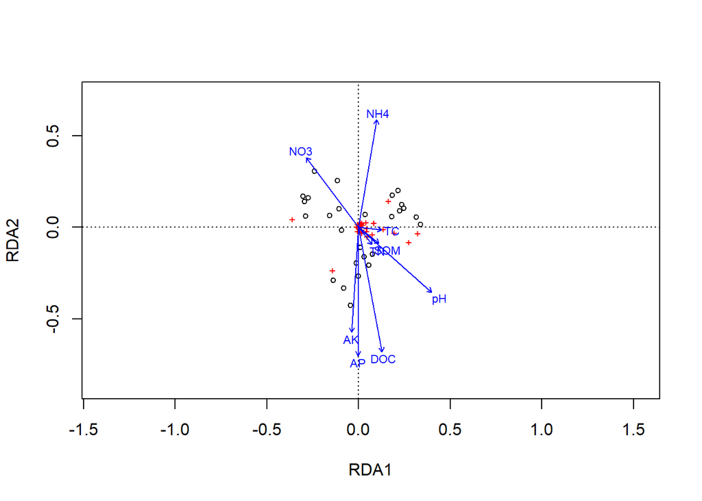

```r
# ordiplot是vegan包自带绘图函数
ordiplot(rda_tb)
```

### 2.plot绘图

**说明**

1. plot()命令中，display参数用于定义在排序图中展示哪些信息，具体见`?plot.cca()`。其中：
   - sp：物种，
   - wa：使用物种加权和计算的样方坐标，
   - lc：以拟合值（解释变量的线性组合）计算样方的坐标，
   - cn：约束成分（即解释变量）。可知对于样方坐标有两种可选展示方式，
2. scores()用于提取物种、样方或环境变量的排序坐标，同样以display参数定义。
3. vegan默认绘图中，排序向量的位置与summary有所不同，原因是做了同比例缩放，以便于展示和分析

**代码1（基础绘图）**

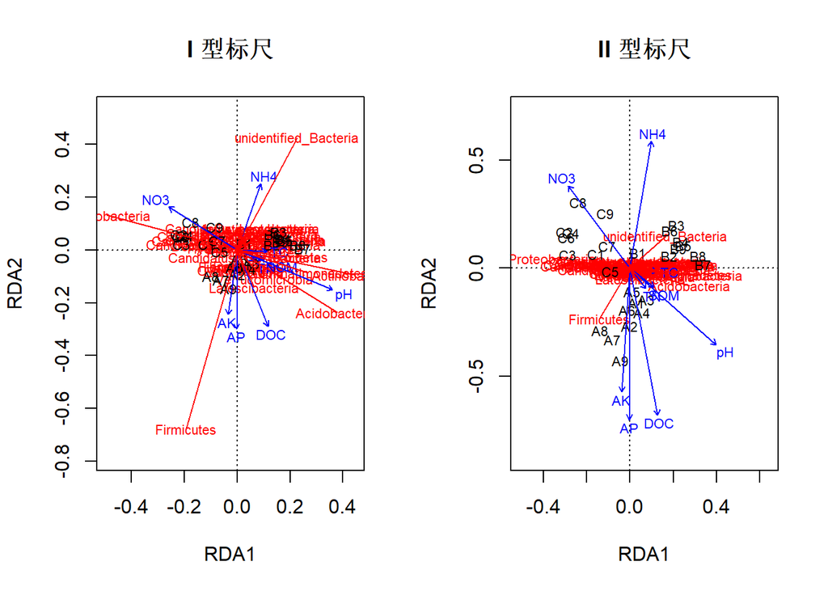

```r
# 对于RDA（更多画图说明，查看plot.cca）
rda_tb <- rda(phylum_hel~., env, scale = FALSE)
rda_tb.scaling1 <- summary(rda_tb, scaling = 1)
par(mfrow = c(1, 2))
# 图1，1型标尺
plot(rda_tb, scaling = 1, main = 'I 型标尺', display = c('wa', 'sp', 'cn'))
rda_sp.scaling1 <- scores(rda_tb, choices = 1:2, scaling = 1, display = 'sp')
arrows(0, 0, rda_sp.scaling1[ ,1], rda_sp.scaling1[ ,2], length =  0, lty = 1, col = 'red')
# 图2，2型标尺
plot(rda_tb, scaling = 2, main = 'II 型标尺', display = c('wa', 'sp', 'cn'))
rda_sp.scaling2 <- scores(rda_tb, choices = 1:2, scaling = 2, display = 'sp')
arrows(0, 0, rda_sp.scaling2[ ,1], rda_sp.scaling2[ ,2], length =  0, lty = 1, col = 'red')
```

**代码2（简要信息绘图）**

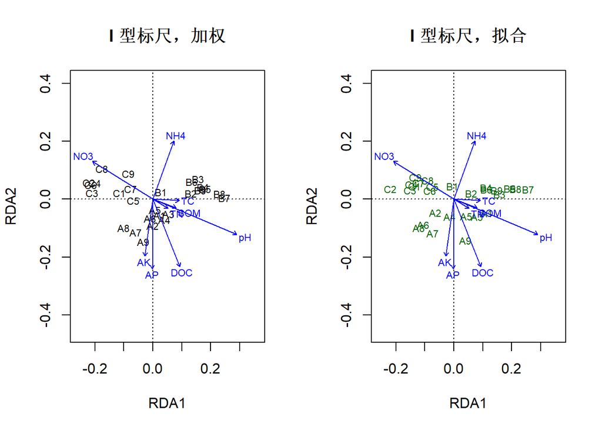

```r
# 隐藏物种信息，以 I 型标尺为例展示双序图，并查看分别使用物种加权计算的样方坐标（wa）以及拟合的样方坐标（lc）的差异
par(mfrow = c(1, 2))
plot(rda_tb, scaling = 1, main = 'I 型标尺，加权', display = c('wa', 'cn'))
plot(rda_tb, scaling = 1, main = 'I 型标尺，拟合', display = c('lc', 'cn'))
```

**代码3（添加点）**

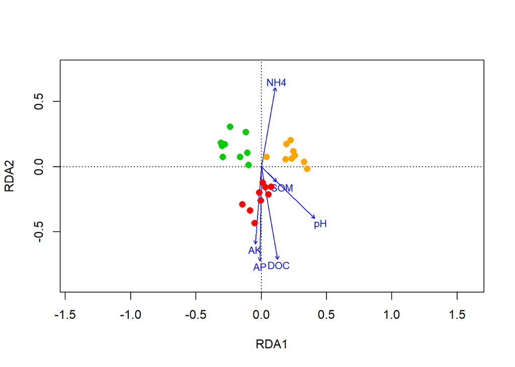

```r
# 以前向选择后的简约模型 rda_tb_forward_r 为例，展示前两轴，II 型标尺，双序图，默认使用物种加权和计算的样方坐标
# rda_tb_forward_r <- ordiR2step(rda(phylum_hel~1, env, scale = FALSE), scope = formula(rda_tb), R2scope = rda_adj, direction = 'forward', permutations = 999)   #建立前向选择模型

plot(rda_tb_forward_r, choices = c(1, 2), scaling = 2, type = 'n')
text(rda_tb_forward_r, choices = c(1, 2), scaling = 2, dis = 'cn', col = 'blue', cex = 0.8)
points(rda_tb_forward_r, choices = c(1, 2), scaling = 2, pch = 21, bg = c(rep('red', 9), rep('orange', 9), rep('green3', 9)), col = NA, cex = 1.2)
```

### 3.ggplot2绘图

**代码1（教程自带）**

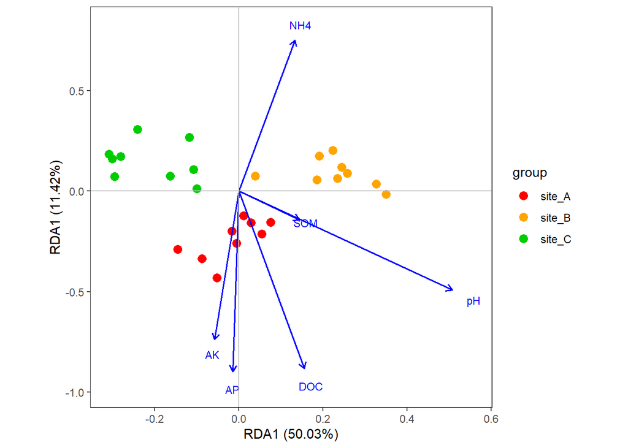

```r
# 使用教程自带数据，代码略有修改
rda.summ <- summary(rda_tb_forward_r, scaling = 2)
plot.sit <- rda.summ$sites  %>% data.frame() %>% '['(1:2)  #提取样本
plot.env <- rda.summ$biplot %>% data.frame() %>% '['(1:2)  #提取环境因子
group <- read.delim('./#data/RDA-01_3_group.txt', sep='\t', stringsAsFactors=F) #读取样本分组数据
plot.sit$sample <- rownames(plot.sit)                      #添加样本名
plot.sit        <- merge(plot.sit, group, by = 'sample')   #合并分组信息
plot.env$index  <- rownames(plot.env)                      #添加环境因子信息
rda.contri <- rda.summ$cont$importance[2,1:2]*100          #提取贡献率
labs.x <- sprintf("RDA1 (%.2f%%)", rda.contri[1])
labs.y <- sprintf("RDA1 (%.2f%%)", rda.contri[2])

#画图
ggplot(plot.sit, aes(RDA1, RDA2)) +
  geom_point(aes(color = group), size=3) +
  geom_segment(data = plot.env, aes(x = 0,y = 0, xend = RDA1, yend = RDA2),
               arrow = arrow(length = unit(0.2, 'cm')), linewidth = 0.6, color = 'blue') +
  geom_text(data = plot.env, aes(RDA1*1.1, RDA2*1.1, label=index), color='blue', size=3)+
  scale_color_manual(values = c('red', 'orange', 'green3')) +
  geom_vline(xintercept = 0, color = 'gray', linewidth = 0.5) +
  geom_hline(yintercept = 0, color = 'gray', linewidth = 0.5) +
  labs(x = labs.x, y = labs.y) +
  theme_bw()+
  theme(aspect.ratio = 1/1,panel.grid = element_blank())
```

**代码2（论文RDA绘图代码）**

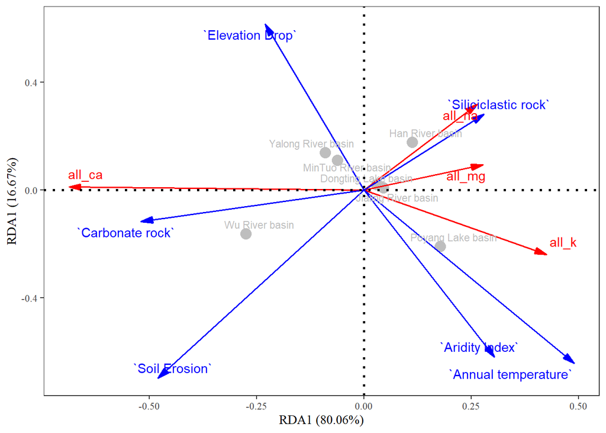

```r
# 加载包
library(data.table)
library(ggplot2)
library(magrittr)
library(vegan)
library(ggrepel)
library(boot)
# 读取数据，这里前几个Al2O3不一样，是因为三个月的数据，先矫正再平均的
rda_tributary <- fread("./#data/RDA-04_1_CSP_tributary.csv")

# rda_tributary列名
#1  id          #2  label      #3  Subbasin    #4  sampling_site #5  dem_min
#6  dem_max     #7  dem_dif    #8  Car_percent #9  Sli_percent   #10 esmean
#11 mPre_year   #12 mPre_month #13 mTem_year   #14 mTem_month    #15 mEt0_year
#16 mEt0_month  #17 AI_year
#18 K2O         #19 Na2O       #20 CaO         #21 MgO
#22 all_k       #23 all_na     #24 all_ca      #25 all_mg        #26 SCP

# 生成数据
col_name <- names(rda_tributary)
col_id   <- c(1,2)
col_y    <- c(22,23,24,25)     #4个被解释变量，CSP钙镁纳钾
col_x    <- c(7,8,9,10,17,13)  #6个解释变量：demdif/car/sli/es/ai/tem
col_y_n  <- length(col_y)
col_x_n  <- length(col_x)
y.colname <- c("K2O","Na2O","CaO","MgO")
x.colname <- c("Elevation Drop", "Carbonate rock",     "Siliciclastic rock",
               "Soil Erosion",   "Aridity Index", "Annual temperature")
dax <- rda_tributary[, .SD, .SDcols = col_x]    #年气温、干旱指数
day <- rda_tributary[, .SD, .SDcols = col_y]    #CSP
dan <- rda_tributary$Subbasin

# bootstrap抽样
# 定义一个函数，用于返回引导样本的均值
bootstrap_function <- function(data, indices) {
  sample_data <- data[indices, ]
  return(as.vector(t(sample_data)))
}
dat     <- cbind(day,dax,dan)
results <- boot(data = dat, statistic = bootstrap_function, R = 50)
datbs   <- matrix(results$t[,1:ncol(dat)], ncol = ncol(dat), byrow = F)
dan2 <- datbs[,col_y_n+col_x_n+1] %>% as.data.frame() %>% set_colnames("name")        #提取样点名
datbs.n <- datbs[,-(col_y_n+col_x_n+1)] %>% as.numeric() %>% matrix(nrow=nrow(datbs)) #转化为数值
day2 <- datbs.n[,1:col_y_n] %>% as.data.frame() %>% set_colnames(y.colname)
dax2 <- datbs.n[,(col_y_n+1):(col_y_n+col_x_n)] %>% as.data.frame() %>% set_colnames(x.colname)

# 计算RDA，有hellinger转换，则属于tb-RDA
day2.h <- decostand(day2,method = "hellinger") # Hellinger转化，适用于物种0值较多情况，
rda.r <- rda(day2.h~.,dax2)
rda.s <- summary(rda.r, scaling = 2)

# 绘图数据
xz <- as.data.frame(rda.s$biplot[,1:2])   #解释变量
yz <- as.data.frame(rda.s$species[,1:2])  #响应变量
st <- as.data.frame(rda.s$site[,1:2])     #样点

# 文字标记位置调整
st_text <- st
st_text$l <- dan2$name
st_text <- unique(st_text)

# RDA轴贡献标记
# 注意不要用下面这个，会导致末位0不显示
# labs(x=paste("RDA 1 (", format(100 *rda.s$cont[[1]][2,1], digits=4), "%)", sep=""),
#      y=paste("RDA 2 (", format(100 *rda.s$cont[[1]][2,2], digits=4), "%)", sep=""))
rda.contri <- rda.s$cont$importance[2,1:2]*100          #提取贡献率
labs.x <- sprintf("RDA1 (%.2f%%)", rda.contri[1])
labs.y <- sprintf("RDA1 (%.2f%%)", rda.contri[2])

# 有无文字画两次图，因为文字有可能重叠，没有文字的图，需手动ps文字
ggplot() +
  geom_point(data = st,aes(RDA1,RDA2),color='gray',size=4)+
  geom_segment(data = yz,aes(x = 0, y = 0, xend = RDA1, yend = RDA2),
               arrow = arrow(angle=15,length = unit(0.35,"cm"), type = "closed"),
               linetype=1, linewidth=0.6, colour="red")+
  geom_segment(data = xz,aes(x = 0, y = 0, xend = RDA1, yend = RDA2),
               arrow = arrow(angle=15,length = unit(0.35,"cm"), type = "closed"),
               linetype=1, linewidth=0.6,colour = "blue")+
  geom_text_repel(data = st_text,aes(RDA1,RDA2,label=l),color='gray',size=3)+
  geom_text_repel(data = yz, aes(RDA1, RDA2), colour="red", label=names(day), parse = T)+
  geom_text_repel(data = xz,aes(RDA1,RDA2,label=row.names(xz)),colour = "blue")+
  geom_hline(yintercept=0,linetype=3,linewidth=1)+
  geom_vline(xintercept=0,linetype=3,linewidth=1)+
  # scale_x_continuous(limits = c(-0.62, 0.62), breaks = round(seq(-0.6,0.6,by=0.2),1))+
  # scale_y_continuous(limits = c(-0.82, 0.82), breaks = seq(-0.8,0.8,by=0.2))+
  labs(x=labs.x, y=labs.y)+
  theme_bw()+
  theme(panel.grid=element_blank(),
        text = element_text(family = "serif"))
```

## 11.完整案例

**说明**

重点展示代码和图，次要展示结果和解释

**代码**

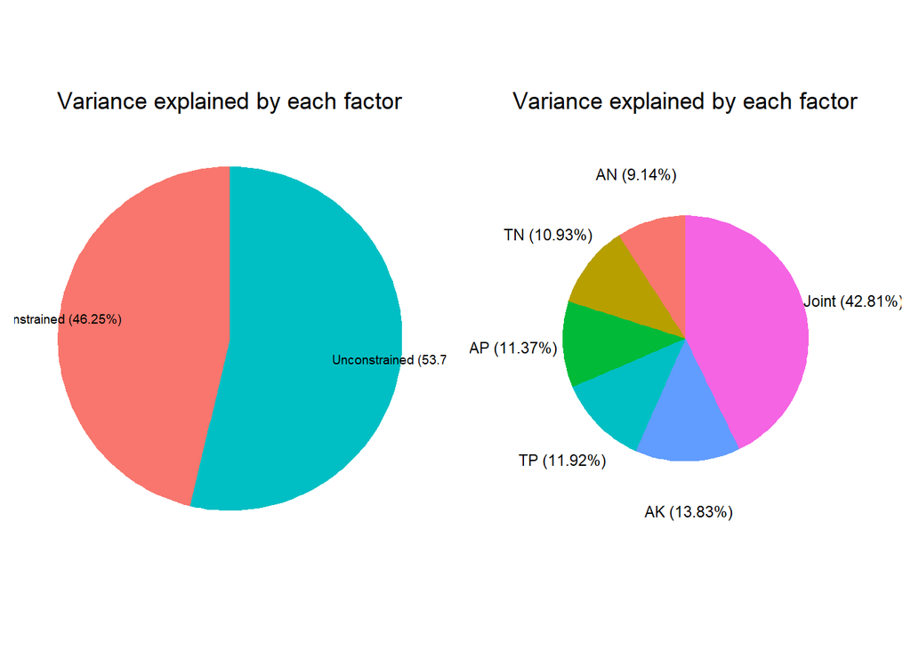

```r
# 加载包
library(vegan)
library(ggplot2)
library(ggrepel)
library(gridExtra)

### 1.数据准备
grp <- read.table('./#data/RDA-05_1_grp.txt', row.names = 1, header = T, sep = '\t')
otu <- read.table("./#data/RDA-05_2_OTU.txt",header=T,row.names = 1, sep = '\t') #读取因变量矩阵
env <- grp[,-c(1:2)]
otu <- otu[,rownames(grp)] %>% .[rowSums(.) !=0,] %>% t() #去除均为0的行，对列排序，转置
otu.helli <- decostand(otu, method = "hellinger") #标准化

### 2. 模型选择
decorana(otu.helli)    #执行DCA去趋势分析：结果都小于3，适合做RDA

### 3. 前向选择构建模型
fit.0   <- rda (otu.helli ~ 1, data = env)               #因变量矩阵和指示变量逐个进行RDA分析
fit.all <- rda (otu.helli ~ ., data = env)               #因变量矩阵与所有环境变量进行RDA分析
fit     <- ordiR2step (fit.0, scope = formula(fit.all))  #执行前向选择

### 4. 模型检验
total <- summary(fit)                 #查看RDA分析结果
vif.cca(fit)                          #方差膨胀因子：结果没有大于10，无线性相关
summary(eigenvals(fit))               #查看每个排序轴的特征值和能够解释的变异
anova.cca(fit)                        #查看RDA模型显著性：结果0.001，显著
anova.cca(fit, by="term", parallel=2) #查看解释变量的显著性：结果前两个AN为0.001，AP为0.005，显著
anova.cca(fit, by="axis")             #查看排序轴的显著性：结果前两轴RDA1为0.001，RDA2为0.001，显著
RsquareAdj(fit)                       #查看R2：结果R2为0.4625488，调整R2为0.3132568
coef(fit)                             #查看典范系数

### 5. 各个环境因子对整体变异的贡献率 #####
# 当前模型（经过前向选择后）包含的环境因子
env.fac <- attr(fit$terms, "term.labels")
# 当前模型的解释能力
expl.tot <- total$tot.chi     #总体方差
expl.con <- total$constr.chi  #变量所能解释的方差
expl.unc <- total$unconst.chi #未解释方差
# 当前模型约束轴内，各环境变量的解释能力
expl.con.fac <- c()
for (i in env.fac){
  di   <- setdiff(env.fac, i)
  trda <- rda(otu.helli, env[i], env[di])    #将其他因子作为控制变量输入RDA
  expl.con.fac <- c(expl.con.fac, trda$CCA$eig)    #结果为环境因子单独解释的特征根
}
expl.con.fac <- c(expl.con.fac, expl.con-sum(expl.con.fac)) #再添一项，为joint部分
names(expl.con.fac) <- c(env.fac, "Joint")
expl.con.fac <- expl.con.fac/expl.con
# 生成画图数据
# 总贡献
prob.com <- c(expl.con, expl.unc)/expl.tot
df.tot <- data.table(class = c("Constrained", "Unconstrained"), prob = prob.com)
df.tot[, lab_y:=cumsum(df.tot$prob) - 0.5*df.tot$prob]
df.tot[, lab_t:=sprintf("%s (%.2f%%)",class,prob*100)]
# 约束贡献
expl.con.fac <- sort(expl.con.fac)
df.con <- data.table(class=factor(names(expl.con.fac), levels = names(expl.con.fac)), prob=expl.con.fac)
df.con[, lab_y:=cumsum(df.con$prob) - 0.5*df.con$prob]
df.con[, lab_t:=sprintf("%s (%.2f%%)",class,prob*100)]

p1 <- ggplot(df.tot, aes(x = 1, y = prob, fill = class))+
  geom_bar(stat = "identity", position = position_stack(reverse = T), width = 1, show.legend = F)+
  geom_text(aes(x = 1.5, y = lab_y, fill = NULL, label = lab_t), color = "black", size = 2.5)+
  coord_polar(theta = "y", direction = -1, start = 0)+
  labs(x = NULL, y = NULL, title = "Variance explained by each factor")+
  theme_bw()+
  theme(aspect.ratio = 1/1,
        axis.ticks = element_blank(),
        axis.text = element_blank(),
        panel.grid = element_blank(),
        panel.border = element_blank(),
        plot.title = element_text(hjust = 0.5))

p2 <- ggplot(df.con, aes(x = 1, y = prob, fill = class))+
  geom_bar(stat = "identity", position = position_stack(reverse = T), width = 1, show.legend = F)+
  geom_text(aes(x = 1.9, y = lab_y, fill = NULL, label = lab_t), color = "black", size = 3)+
  coord_polar(theta = "y", direction = -1, start = 0)+
  labs(x = NULL, y = NULL, title = "Variance explained by each factor")+
  theme_bw()+
  theme(aspect.ratio = 1/1,
        axis.ticks = element_blank(),
        axis.text = element_blank(),
        panel.grid = element_blank(),
        panel.border = element_blank(),
        plot.title = element_text(hjust = 0.5))
grid.arrange(p1, p2, ncol = 2)
```

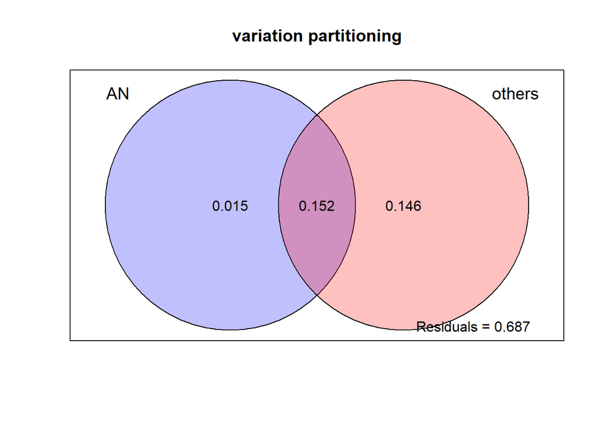

```r
# 注意以上过程与方差分解不同
# rdacca.hpf变差分解
# library(rdacca.hp)
# rdacca.hp(otu.helli, env[env.fac], method = "RDA", type = "adjR2", var.part = F)
# $Method_Type
# [1] "RDA"   "adjR2"
# $Total_explained_variation
# [1] 0.313
# $Hier.part
# Unique Average.share Individual I.perc(%)
# AN 0.0150        0.0867     0.1017     32.49
# AP 0.0275        0.0188     0.0463     14.79
# TP 0.0306        0.0130     0.0436     13.93
# AK 0.0413       -0.0010     0.0403     12.88
# TN 0.0251        0.0563     0.0814     26.01
# attr(,"class")
# [1] "rdaccahp"

# vegan变差分解
vp_1 <- varpart(otu.helli, env[env.fac[1]], env[env.fac[-1]])
plot(vp_1, digits = 2, Xnames = c(env.fac[1], 'others'), bg = c('blue', 'red'), main="variation partitioning")
title(main = "variation partitioning")
```

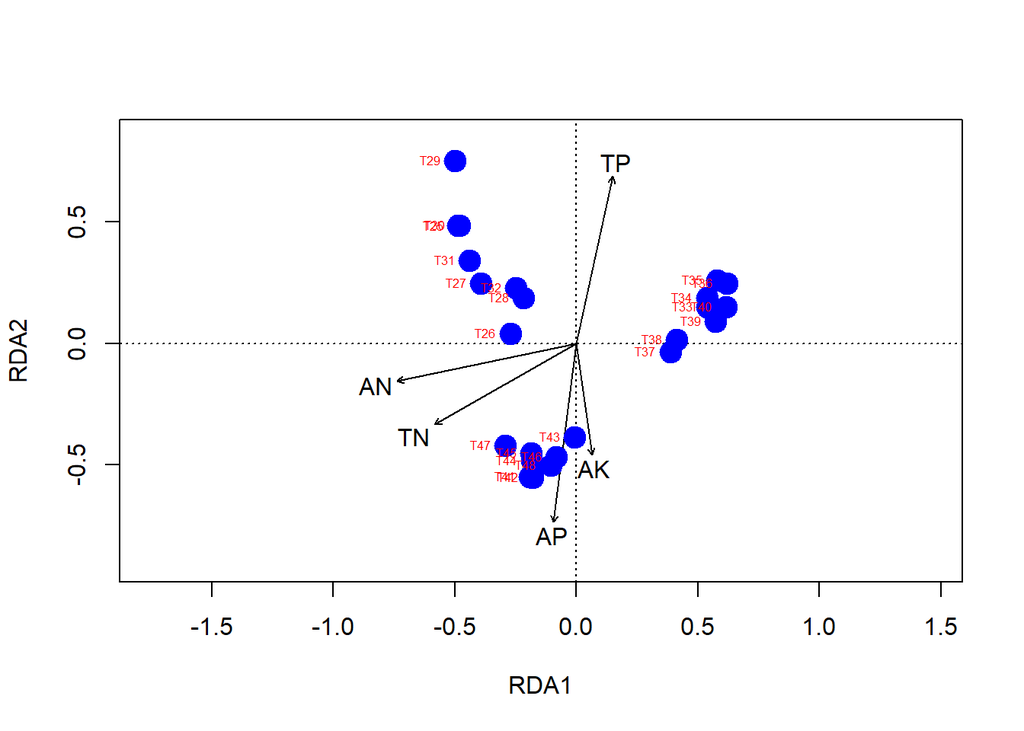

```r
### 6. 基本绘图
plot(fit, type="n")
text(fit, dis="cn")
points(fit, pch=21, col="blue", bg="blue", cex=2)
text(fit, "sites", col='red', cex=0.5,  adj = 0.5, pos=2)
```

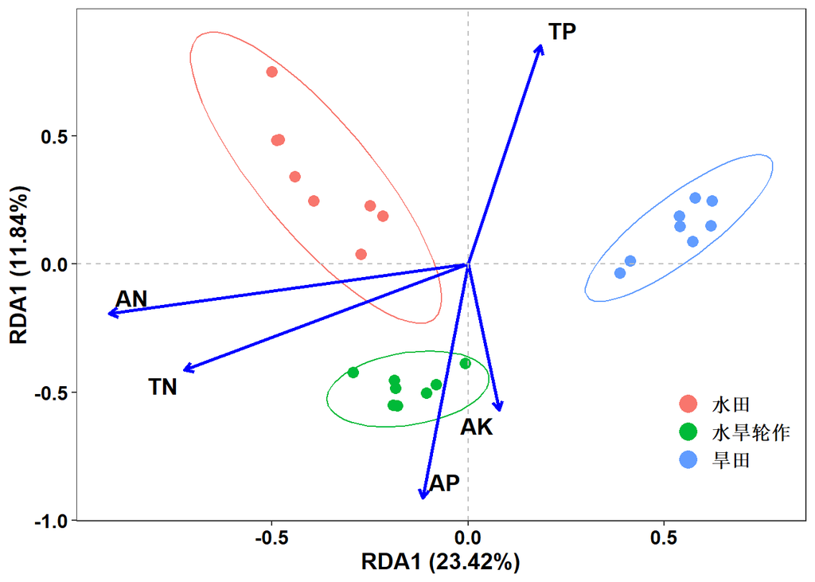

```r
### 7. 使用ggplot2绘图
# 获取样点坐标
sites <- total$sites[,1:2] %>% data.frame() %>% merge(grp[,1:2],by = 'row.names')

# 获取指示变量坐标
biplot <- total$biplot[,1:2] %>% data.frame()
biplot$env <- rownames(biplot)

# 定义样点组合在图例中的出场顺序
sites$treatment <- factor(sites$treatment, levels = c('S','SH','H'))
# 重命名，须注意与上面的对应关系
levels(sites$treatment) = c('水田','水旱轮作','旱田')
rda.contri <- total$cont$importance[2,1:2]*100               #提取贡献率
labs.x <- sprintf("RDA1 (%.2f%%)", rda.contri[1])
labs.y <- sprintf("RDA1 (%.2f%%)", rda.contri[2])

ggplot(sites, aes(x = RDA1, y = RDA2, color = treatment)) +
  geom_point(size = 3) +
  stat_ellipse(show.legend = F) +                            #添加置信区间，点的包围线
  geom_segment(data = biplot,
               aes(x = 0, y = 0, xend = RDA1, yend = RDA2),
               arrow = arrow(length = unit(1/2, 'picas')), lwd = 1,
               colour = "blue") +                            #添加箭头
  guides(color = guide_legend(override.aes = list(size=5)))+ #增加图例中点的大小
  geom_hline(yintercept=0, linetype=2,color='grey') +        #添加经过坐标原点的横线
  geom_vline(xintercept=0, linetype=2,color='grey') +        #添加经过坐标原点的纵线
  geom_text_repel(data = biplot,
                  aes(x=RDA1,y=RDA2,label=env),
                  size= 5, fontface='bold',color='black')+ #添加指示变量文本
  labs(x = labs.x, y = labs.y, color = '') +
  theme_bw() +
  theme(legend.position = "inside",
        legend.position.inside = c(0.9,0.2),
        legend.background = element_blank(),
        legend.text = element_text(face = 'bold',color='black',size=12),
        axis.title = element_text(face = 'bold',color='black',size=14),
        axis.text = element_text(face = 'bold',color='black',size=12),
        panel.grid = element_blank())
```